# Reproducing results in ‘Geometric ergodicity of trans-dimensional Markov chain Monte Carlo algorithms’

# Introduction

This R Markdown file serves as a guide for reproducing the results from the paper “Geometric Ergodicity of Trans-dimensional Markov Chain Monte Carlo Algorithms.” The knitting process takes several minutes. Code chunks that require significant computation are not evaluated by default, as indicated by `eval=FALSE` at the start of the respective code chunks. Instead, their results are preloaded from the “output” folder. If you wish to run these chunks manually, you can set `eval=TRUE`, while disabling the corresponding chunks that load the precomputed results. Be aware that evaluating all code chunks may take several hours.

The following packages are used:

```r
library(LaplacesDemon)
library(ggplot2)
library(mvtnorm)
library(statmod)
library(truncnorm)
library(dplyr)
library(patchwork)
library(MASS)
```

# Section 4.1

## First plot in Figure 1

Let $k_{\scriptsize\mbox{max}} = 15$, and let $n = 5, 10, ..., 40$. Below we calculate the true values and bounds for $\|P\|_{\Pi}$. We will rely on functions in the file “functions_4_1.R”.

```r
source("functions_4_1.R", local = knitr::knit_global())
```

$\|P\|_{\Pi}$ and its bound are calculated below. Note that $k_{\scriptsize\mbox{max}}$ is called `kmax`, and $n$ is called `Zksize`.

```r
kmax <- 15
# num.points gives the number of Zksize values that will be studied.
num.points <- 8
# For each kmax and Zksize, there are 6 configurations for the myGl/myLo combination. "myGl" gives the global move type, and can be fast or slow; "myLo" gives the local move type, and can be fast, slow, or varied.
Zksize.seq <- Gl.seq <- Lo.seq <- truth.seq <- bound.seq <- rep(0,6*num.points)

for (myGl in 1:2) {
  for (myLo in 1:3) {
    for (i in 1:num.points) {
      index <- (myGl-1)*3*num.points + (myLo-1)*num.points + i
      Zksize.seq[index] <- 5*i
      Gl.seq[index] <- c("fast","slow")[myGl]
      Lo.seq[index] <- c("fast","slow","varied")[myLo]
      temp <- getbound(kmax,5*i,c("fast","slow")[myGl],c("fast","slow","varied")[myLo],F)

      # The truth and the bounds are in terms of $1 - \|P\|_{\Pi}$.
      truth.seq[index] <- temp$truth
      bound.seq[index] <- temp$bound
    }
  }
}

df.numeric.Zksize <- data.frame(Zksize=Zksize.seq, Global=Gl.seq, Local=Lo.seq, truth=truth.seq, bound=bound.seq)
```

Plotting the result gives the first plot in Figure 1 of the manuscript.

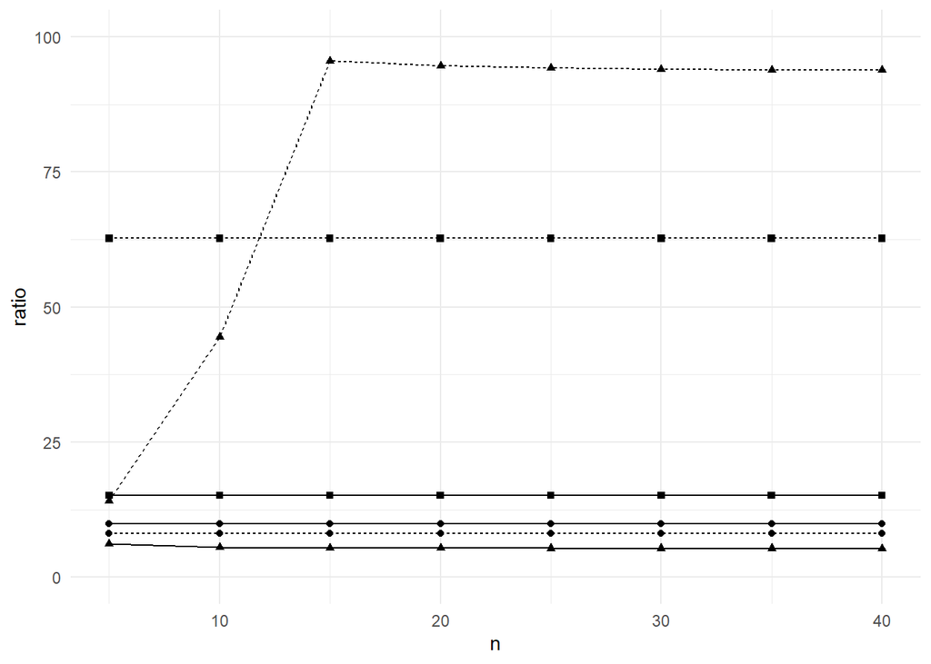

```r
p.numeric.Zksize <- ggplot(data=df.numeric.Zksize, aes(x=Zksize, y=truth/bound, group=interaction(Global,Local))) +
  theme_minimal() + geom_line(aes(linetype=Global)) + geom_point(aes(shape=Local)) +
  labs(x="n", y="ratio") + ylim(0,100) + theme(legend.position="none")

p.numeric.Zksize
```

## Second plot in Figure 1

Let $k_{\scriptsize\mbox{max}} = 5, 10, ..., 40$, and let $n = 15$. We calculate the true values and bounds for $\|P\|_{\Pi}$ using the code below.

```r
Zksize <- 15
num.points <- 8
kmax.seq <- Gl.seq <- Lo.seq <- truth.seq <- bound.seq <- rep(0,6*num.points)

for (myGl in 1:2) {
  for (myLo in 1:3) {
    for (i in 1:num.points) {
      index <- (myGl-1)*3*num.points + (myLo-1)*num.points + i
      kmax.seq[index] <- 5*i
      Gl.seq[index] <- c("fast","slow")[myGl]
      Lo.seq[index] <- c("fast","slow","varied")[myLo]
      temp <- getbound(kmax.seq[index],Zksize,c("fast","slow")[myGl],c("fast","slow","varied")[myLo],F)
      truth.seq[index] <- temp$truth
      bound.seq[index] <- temp$bound
    }
  }
}

df.numeric.kmax <- data.frame(kmax=kmax.seq, Global=Gl.seq, Local=Lo.seq, truth=truth.seq, bound=bound.seq)
```

Plotting the result gives the second plot in Figure 1 of the manuscript.

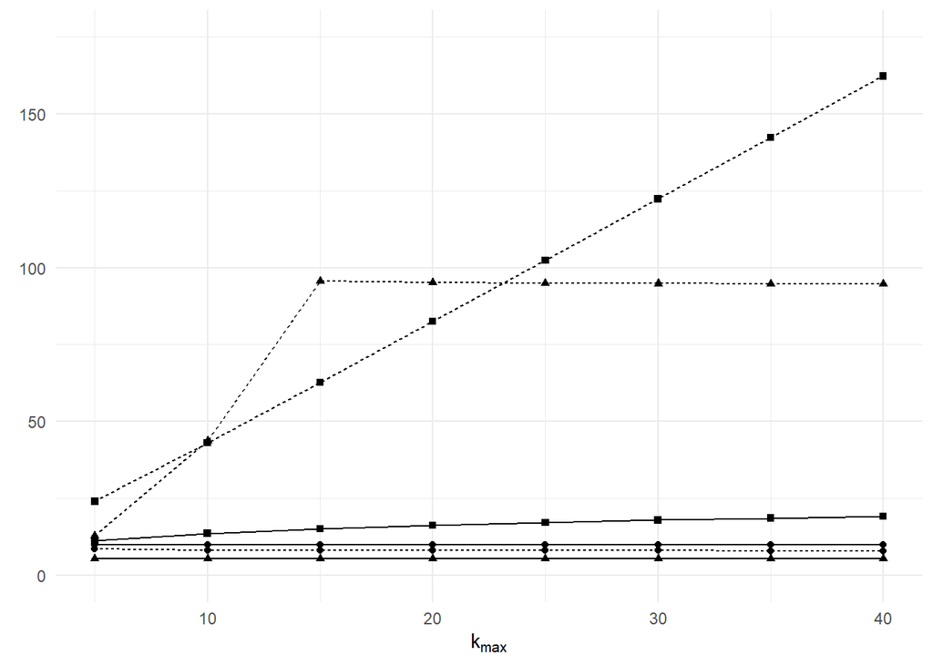

## Third plot in Figure 1

This plot compares the bounds on $1-\|P\|_{\Pi}$ produced by equations (4) and (5) in the manuscript. Let $k_{\scriptsize\mbox{max}} = 5, 10, ..., 40$, and let $n = 15$. We calculate the bounds for $\|P\|_{\Pi}$ via the two equations.

```r
Zksize <- 15
num.points <- 8
kmax.seq <- Zksize.seq <- Gl.seq <- Lo.seq <- bound.nonrev.seq <- bound.rev.seq <- rep(0,6*num.points)
for (myGl in 1:2) {
  for (myLo in 1:3) {
    for (i in 1:num.points) {
      index <- (myGl-1)*3*num.points + (myLo-1)*num.points + i
      kmax.seq[index] <- 5*i
      Zksize.seq[index] <- Zksize
      Gl.seq[index] <- c("fast","slow")[myGl]
      Lo.seq[index] <- c("fast","slow","varied")[myLo]
      temp <- getbound(kmax.seq[index],Zksize.seq[index],c("fast","slow")[myGl],c("fast","slow","varied")[myLo],F)
      bound.nonrev.seq[index] <- temp$bound # bound based on (4)
      temp <- getbound(kmax.seq[index],Zksize.seq[index],c("fast","slow")[myGl],c("fast","slow","varied")[myLo],T)
      bound.rev.seq[index] <- temp$bound # bound based on (5)
    }
  }
}

df.numeric.rev <- data.frame(kmax=kmax.seq, Zksize=Zksize.seq, Global=Gl.seq, Local=Lo.seq, bound.nonrev=bound.nonrev.seq, bound.rev=bound.rev.seq)
```

Plotting the result gives the third plot in Figure 1.

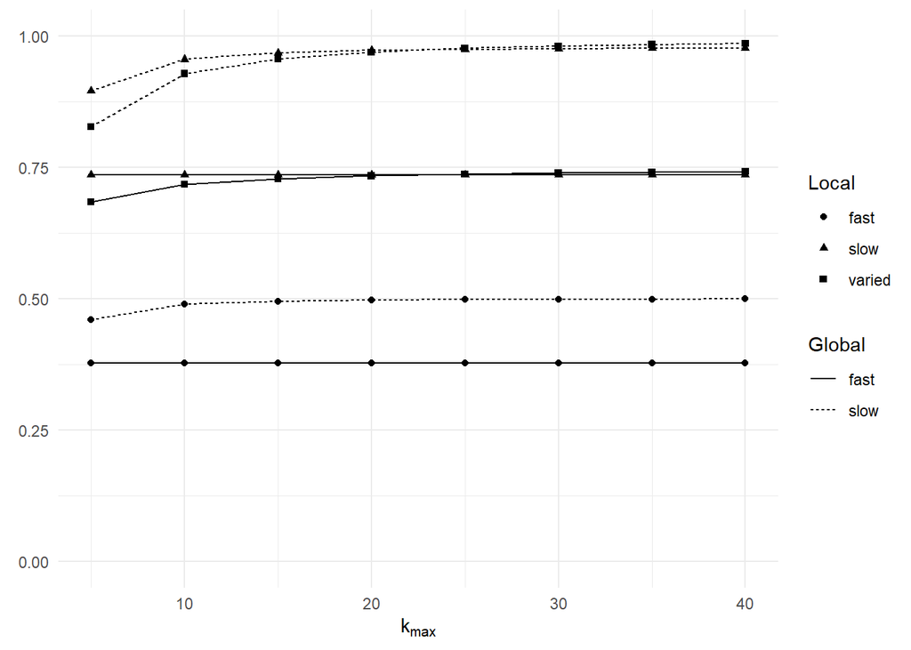